[figure not shown]

# The Thematic map

Last session we created a file with several layers:

```python
import geopandas as gpd

linkGit='https://github.com/a20202124/PC1_Chinchay_David/raw/refs/heads/main/'
linkWorldMaps='worldMaps.gpkg'
```

we can easily find out the layers in that geopackage file (**worldMaps.gpkg**):

```python
gpd.list_layers(linkGit+linkWorldMaps)
```

|  | name | geometry_type |
| --- | --- | --- |
| 0 | rivers | MultiLineString |
| 1 | cities | Point |
| 2 | countries | MultiPolygon |

For the thematics we will retrieve only one layer (map):

```python
countries=gpd.read_file(linkGit+linkWorldMaps,layer='countries')

# see some
countries
```

|  | COUNTRY | geometry |
| --- | --- | --- |
| 0 | Aruba (Netherlands) | MULTIPOLYGON (((-69.88223 12.41111, -69.94695 ... |
| 1 | Antigua and Barbuda | MULTIPOLYGON (((-61.73889 17.54055, -61.75195 ... |
| 2 | Afghanistan | MULTIPOLYGON (((61.27656 35.60725, 61.29638 35... |
| 3 | Algeria | MULTIPOLYGON (((-5.15213 30.18047, -5.13917 30... |
| 4 | Azerbaijan | MULTIPOLYGON (((46.54037 38.87559, 46.49554 38... |
| ... | ... | ... |
| 247 | South Sudan | MULTIPOLYGON (((34.21807 9.96458, 34.20722 9.9... |
| 248 | Indonesia | MULTIPOLYGON (((123.21846 -10.80917, 123.19832... |
| 249 | East Timor | MULTIPOLYGON (((124.41824 -9.3001, 124.40446 -... |
| 250 | Curacao (Netherlands) | MULTIPOLYGON (((-68.96556 12.19889, -68.91196 ... |
| 251 | Bonaire (Netherlands) | MULTIPOLYGON (((-68.19736 12.22264, -68.19292 ... |

252 rows × 2 columns

As you see, the GDF above has just two colums; enough to plot a map, but no more than that.

Let me open a DF:

```python
import pandas as pd

someDataLink='Death_rate.csv'

someData=pd.read_csv(linkGit+someDataLink)

## data available
someData.info()
```

```
<class 'pandas.core.frame.DataFrame'>
RangeIndex: 229 entries, 0 to 228
Data columns (total 7 columns):
 #   Column               Non-Null Count  Dtype
---  ------               --------------  -----
 0   name                 229 non-null    object
 1   slug                 229 non-null    object
 2    deaths/1            229 non-null    float64
 3   000 population       229 non-null    int64
 4   date_of_information  229 non-null    int64
 5   ranking              229 non-null    object
 6   region               0 non-null      float64
dtypes: float64(2), int64(2), object(3)
memory usage: 12.7+ KB
```

## Pre Processing: Merging

There are also other columns that may be of help:

```python
someData.head()
```

|  | name | slug | deaths/1 | 000 population | date_of_information | ranking | region |
| --- | --- | --- | --- | --- | --- | --- | --- |
| 0 | Ukraine | ukraine | 18.6 | 2024 | 1 | Europe | NaN |
| 1 | Lithuania | lithuania | 15.2 | 2024 | 2 | Europe | NaN |
| 2 | Serbia | serbia | 14.9 | 2024 | 3 | Europe | NaN |
| 3 | Latvia | latvia | 14.7 | 2024 | 4 | Europe | NaN |
| 4 | Romania | romania | 14.6 | 2024 | 5 | Europe | NaN |

Preparing thematic maps requires **social data** *about* the geometry (line, polygon, point). The object **countries** has no social data, so the preprocessing requires geomerging.

### Geo Merging

This is a critical preprocessing operation, as it is in charge of combining data sets, in this case combine a DF into a GDF. Some rules are needed:

- There is at least one common column needed to serve for the matches.
- The common columns, or KEYs, need contents to be written exactly in both columns.
- It is recommended that both KEYs are named the same.

Here we have the KEYs:

```python
countries.COUNTRY.head()
```

```
0    Aruba (Netherlands)
1    Antigua and Barbuda
2            Afghanistan
3                Algeria
4             Azerbaijan
Name: COUNTRY, dtype: object
```

```python
someData.name.head()
```

```
0      Ukraine
1    Lithuania
2       Serbia
3       Latvia
4      Romania
Name: name, dtype: object
```

Let's solve the *country name* differences for the KEYs:

```python
countries.rename(columns={'COUNTRY':'name'},inplace=True)
```

It is very unlikely the names are written the same. Let's verify:

```python
onlyDF=set(someData.name)- set(countries.name)
onlyGDF=set(countries.name)- set(someData.name)
```

Check here:

```python
onlyDF # they did not find a match in the MAP GDF!
```

```
{'American Samoa',
 'Anguilla',
 'Aruba',
 'Bahamas, The',
 'Bermuda',
 'British Virgin Islands',
 'Burma',
 'Cabo Verde',
 'Cayman Islands',
 'Cocos (Keeling) Islands',
 'Congo, Democratic Republic of the',
 'Congo, Republic of the',
 'Cook Islands',
 "Cote d'Ivoire",
 'Curacao',
 'Czechia',
 'Eswatini',
 'Falkland Islands (Islas Malvinas)',
 'Faroe Islands',
 'French Polynesia',
 'Gambia, The',
 'Gaza Strip',
 'Gibraltar',
 'Greenland',
 'Guam',
 'Guernsey',
 'Hong Kong',
 'Isle of Man',
 'Jersey',
 'Korea, North',
 'Korea, South',
 'Kosovo',
 'Macau',
 'Micronesia, Federated States of',
 'Montserrat',
 'New Caledonia',
 'North Macedonia',
 'Northern Mariana Islands',
 'Palau',
 'Puerto Rico',
 'Saint Barthelemy',
 'Saint Helena, Ascension, and Tristan da Cunha',
 'Saint Kitts and Nevis',
 'Saint Lucia',
 'Saint Martin',
 'Saint Pierre and Miquelon',
 'Saint Vincent and the Grenadines',
 'Samoa',
 'Sint Maarten',
 'Timor-Leste',
 'Turkey (Turkiye)',
 'Turks and Caicos Islands',
 'Virgin Islands',
 'Wallis and Futuna',
 'West Bank'}
```

There are several countries in the DF that did not find a match in the GDF (map). Of course, most of them are in the map, let's see why they were not matched.

### Fuzzy merging

We use this technique to detect similarities between strings. You need this package **thefuzz** (based on the [Levenshtein algorithm](https://en.wikipedia.org/wiki/Levenshtein_distance)):

```python
 %pip install --user thefuzz
```

This is the basic idea:

```python
from thefuzz.process import extractOne as best

## find the BEST match to 'BAHAMAS (THE)'
## from all strings in 'onlyGDF'

best('Finland',onlyGDF)
```

```
('Greenland (Denmark)', 71)
```

Let's do the same for all the unmatched countries:

```python
## for each country in onlyDF, find the BEST match in onlyGDF

[(name, best(name,onlyGDF)) for name in onlyDF]
```

```
[('Saint Helena, Ascension, and Tristan da Cunha',
  ('Wallis and Futuna (France)', 86)),
 ('Northern Mariana Islands', ('Northern Mariana Islands (US)', 95)),
 ('Hong Kong', ('Congo', 68)),
 ('Gibraltar', ('Gibraltar (UK)', 95)),
 ('Wallis and Futuna', ('Wallis and Futuna (France)', 95)),
 ('Palau', ('Palau (US)', 90)),
 ('Cabo Verde', ('Cape Verde', 80)),
 ('Saint Kitts and Nevis', ('St. Kitts and Nevis', 90)),
 ('Puerto Rico', ('Puerto Rico (US)', 95)),
 ('Isle of Man', ('Isle of Man (UK)', 95)),
 ('Jersey', ('Jersey (UK)', 90)),
 ('American Samoa', ('American Samoa (US)', 95)),
 ('Bermuda', ('Bermuda (UK)', 90)),
 ('Sint Maarten', ('Myanmar', 62)),
 ('Anguilla', ('Anguilla (UK)', 90)),
 ('Cayman Islands', ('Cayman Islands (UK)', 95)),
 ('Saint Barthelemy', ('Swaziland', 55)),
 ("Cote d'Ivoire", ('Ivory Coast', 63)),
 ('French Polynesia', ('French Polynesia (France)', 90)),
 ('Faroe Islands', ('Faroe Islands (Denmark)', 90)),
 ('Samoa', ('Western Samoa', 90)),
 ('Aruba', ('Aruba (Netherlands)', 90)),
 ('Congo, Republic of the', ('Democratic Republic of the Congo', 95)),
 ('Saint Lucia', ('St. Lucia', 80)),
 ('Saint Vincent and the Grenadines', ('St. Vincent and the Grenadines', 94)),
 ('Turkey (Turkiye)', ('Turkey', 90)),
 ('Macau', ('Macedonia', 68)),
 ('New Caledonia', ('New Caledonia (France)', 90)),
 ('Virgin Islands', ('American Virgin Islands (US)', 90)),
 ('Korea, South', ('South Korea', 95)),
 ('Cook Islands', ('Cook Islands (New Zealand)', 90)),
 ('Timor-Leste', ('East Timor', 81)),
 ('North Macedonia', ('Macedonia', 90)),
 ('Saint Pierre and Miquelon',
  ('South Georgia and the South Sandwich Is (UK)', 86)),
 ('Guernsey', ('Guernsey (UK)', 90)),
 ('Czechia', ('Czech Republic', 75)),
 ('Curacao', ('Curacao (Netherlands)', 90)),
 ('West Bank', ('Western Sahara', 57)),
 ('Cocos (Keeling) Islands', ('Cocos (Keeling) Islands (Australia)', 95)),
 ('Bahamas, The', ('Bahamas', 90)),
 ('Saint Martin', ('Antarctica', 64)),
 ('Micronesia, Federated States of', ('Federated States of Micronesia', 95)),
 ('Eswatini', ('Martinique (France)', 60)),
 ('Congo, Democratic Republic of the',
  ('Democratic Republic of the Congo', 95)),
 ('Greenland', ('Greenland (Denmark)', 90)),
 ('Montserrat', ('Montserrat (UK)', 95)),
 ('Turks and Caicos Islands', ('Turks and Caicos Islands (UK)', 95)),
 ('Guam', ('Guam (US)', 90)),
 ('Korea, North', ('North Korea', 95)),
 ('Kosovo', ('South Georgia and the South Sandwich Is (UK)', 45)),
 ('British Virgin Islands', ('British Virgin Islands(UK)', 95)),
 ('Burma', ('Curacao (Netherlands)', 60)),
 ('Falkland Islands (Islas Malvinas)', ('Falkland Islands (UK)', 86)),
 ('Gambia, The', ('Gambia', 90)),
 ('Gaza Strip', ('Gambia', 54))]
```

Each element in the *list* above in in parentheses, for instance:

```
('TIMOR-LESTE', ('EAST TIMOR', 81))
```

That element has two elements:

- **'TIMOR-LESTE'** from *onlyDF*, and
- **('EAST TIMOR', 81)** which is the result from *best(country,onlyGDF)*. This last element, as we just saw above, shows the best match and the level of similarity (the higher the more similar).

We can prepare a list where each element has three elements:

```python
#or
[(name, best(name,onlyGDF)[0],best(name,onlyGDF)[1]) for name in onlyDF]
```

```
[('Saint Helena, Ascension, and Tristan da Cunha',
  'Wallis and Futuna (France)',
  86),
 ('Northern Mariana Islands', 'Northern Mariana Islands (US)', 95),
 ('Hong Kong', 'Congo', 68),
 ('Gibraltar', 'Gibraltar (UK)', 95),
 ('Wallis and Futuna', 'Wallis and Futuna (France)', 95),
 ('Palau', 'Palau (US)', 90),
 ('Cabo Verde', 'Cape Verde', 80),
 ('Saint Kitts and Nevis', 'St. Kitts and Nevis', 90),
 ('Puerto Rico', 'Puerto Rico (US)', 95),
 ('Isle of Man', 'Isle of Man (UK)', 95),
 ('Jersey', 'Jersey (UK)', 90),
 ('American Samoa', 'American Samoa (US)', 95),
 ('Bermuda', 'Bermuda (UK)', 90),
 ('Sint Maarten', 'Myanmar', 62),
 ('Anguilla', 'Anguilla (UK)', 90),
 ('Cayman Islands', 'Cayman Islands (UK)', 95),
 ('Saint Barthelemy', 'Swaziland', 55),
 ("Cote d'Ivoire", 'Ivory Coast', 63),
 ('French Polynesia', 'French Polynesia (France)', 90),
 ('Faroe Islands', 'Faroe Islands (Denmark)', 90),
 ('Samoa', 'Western Samoa', 90),
 ('Aruba', 'Aruba (Netherlands)', 90),
 ('Congo, Republic of the', 'Democratic Republic of the Congo', 95),
 ('Saint Lucia', 'St. Lucia', 80),
 ('Saint Vincent and the Grenadines', 'St. Vincent and the Grenadines', 94),
 ('Turkey (Turkiye)', 'Turkey', 90),
 ('Macau', 'Macedonia', 68),
 ('New Caledonia', 'New Caledonia (France)', 90),
 ('Virgin Islands', 'American Virgin Islands (US)', 90),
 ('Korea, South', 'South Korea', 95),
 ('Cook Islands', 'Cook Islands (New Zealand)', 90),
 ('Timor-Leste', 'East Timor', 81),
 ('North Macedonia', 'Macedonia', 90),
 ('Saint Pierre and Miquelon',
  'South Georgia and the South Sandwich Is (UK)',
  86),
 ('Guernsey', 'Guernsey (UK)', 90),
 ('Czechia', 'Czech Republic', 75),
 ('Curacao', 'Curacao (Netherlands)', 90),
 ('West Bank', 'Western Sahara', 57),
 ('Cocos (Keeling) Islands', 'Cocos (Keeling) Islands (Australia)', 95),
 ('Bahamas, The', 'Bahamas', 90),
 ('Saint Martin', 'Antarctica', 64),
 ('Micronesia, Federated States of', 'Federated States of Micronesia', 95),
 ('Eswatini', 'Martinique (France)', 60),
 ('Congo, Democratic Republic of the', 'Democratic Republic of the Congo', 95),
 ('Greenland', 'Greenland (Denmark)', 90),
 ('Montserrat', 'Montserrat (UK)', 95),
 ('Turks and Caicos Islands', 'Turks and Caicos Islands (UK)', 95),
 ('Guam', 'Guam (US)', 90),
 ('Korea, North', 'North Korea', 95),
 ('Kosovo', 'South Georgia and the South Sandwich Is (UK)', 45),
 ('British Virgin Islands', 'British Virgin Islands(UK)', 95),
 ('Burma', 'Curacao (Netherlands)', 60),
 ('Falkland Islands (Islas Malvinas)', 'Falkland Islands (UK)', 86),
 ('Gambia, The', 'Gambia', 90),
 ('Gaza Strip', 'Gambia', 54)]
```

For instace, this element has 3 elements:

[output not shown]

The level of similarity would guide us to make update (replace) the strings in one of the KEYs, so that the merging process works properly.

Then, it would be better if we have a data frame instead of a list:

```python
pd.DataFrame([(name, best(name,onlyGDF)[0],best(name,onlyGDF)[1]) for name in onlyDF])
```

|  | 0 | 1 | 2 |
| --- | --- | --- | --- |
| 0 | Saint Helena, Ascension, and Tristan da Cunha | Wallis and Futuna (France) | 86 |
| 1 | Northern Mariana Islands | Northern Mariana Islands (US) | 95 |
| 2 | Hong Kong | Congo | 68 |
| 3 | Gibraltar | Gibraltar (UK) | 95 |
| 4 | Wallis and Futuna | Wallis and Futuna (France) | 95 |
| 5 | Palau | Palau (US) | 90 |
| 6 | Cabo Verde | Cape Verde | 80 |
| 7 | Saint Kitts and Nevis | St. Kitts and Nevis | 90 |
| 8 | Puerto Rico | Puerto Rico (US) | 95 |
| 9 | Isle of Man | Isle of Man (UK) | 95 |
| 10 | Jersey | Jersey (UK) | 90 |
| 11 | American Samoa | American Samoa (US) | 95 |
| 12 | Bermuda | Bermuda (UK) | 90 |
| 13 | Sint Maarten | Myanmar | 62 |
| 14 | Anguilla | Anguilla (UK) | 90 |
| 15 | Cayman Islands | Cayman Islands (UK) | 95 |
| 16 | Saint Barthelemy | Swaziland | 55 |
| 17 | Cote d'Ivoire | Ivory Coast | 63 |
| 18 | French Polynesia | French Polynesia (France) | 90 |
| 19 | Faroe Islands | Faroe Islands (Denmark) | 90 |
| 20 | Samoa | Western Samoa | 90 |
| 21 | Aruba | Aruba (Netherlands) | 90 |
| 22 | Congo, Republic of the | Democratic Republic of the Congo | 95 |
| 23 | Saint Lucia | St. Lucia | 80 |
| 24 | Saint Vincent and the Grenadines | St. Vincent and the Grenadines | 94 |
| 25 | Turkey (Turkiye) | Turkey | 90 |
| 26 | Macau | Macedonia | 68 |
| 27 | New Caledonia | New Caledonia (France) | 90 |
| 28 | Virgin Islands | American Virgin Islands (US) | 90 |
| 29 | Korea, South | South Korea | 95 |
| 30 | Cook Islands | Cook Islands (New Zealand) | 90 |
| 31 | Timor-Leste | East Timor | 81 |
| 32 | North Macedonia | Macedonia | 90 |
| 33 | Saint Pierre and Miquelon | South Georgia and the South Sandwich Is (UK) | 86 |
| 34 | Guernsey | Guernsey (UK) | 90 |
| 35 | Czechia | Czech Republic | 75 |
| 36 | Curacao | Curacao (Netherlands) | 90 |
| 37 | West Bank | Western Sahara | 57 |
| 38 | Cocos (Keeling) Islands | Cocos (Keeling) Islands (Australia) | 95 |
| 39 | Bahamas, The | Bahamas | 90 |
| 40 | Saint Martin | Antarctica | 64 |
| 41 | Micronesia, Federated States of | Federated States of Micronesia | 95 |
| 42 | Eswatini | Martinique (France) | 60 |
| 43 | Congo, Democratic Republic of the | Democratic Republic of the Congo | 95 |
| 44 | Greenland | Greenland (Denmark) | 90 |
| 45 | Montserrat | Montserrat (UK) | 95 |
| 46 | Turks and Caicos Islands | Turks and Caicos Islands (UK) | 95 |
| 47 | Guam | Guam (US) | 90 |
| 48 | Korea, North | North Korea | 95 |
| 49 | Kosovo | South Georgia and the South Sandwich Is (UK) | 45 |
| 50 | British Virgin Islands | British Virgin Islands(UK) | 95 |
| 51 | Burma | Curacao (Netherlands) | 60 |
| 52 | Falkland Islands (Islas Malvinas) | Falkland Islands (UK) | 86 |
| 53 | Gambia, The | Gambia | 90 |
| 54 | Gaza Strip | Gambia | 54 |

Let's sort by the column '2' (the third):

```python
pd.DataFrame([(name, best(name,onlyGDF)[0],best(name,onlyGDF)[1]) for name in onlyDF]).sort_values(by=2)
```

|  | 0 | 1 | 2 |
| --- | --- | --- | --- |
| 49 | Kosovo | South Georgia and the South Sandwich Is (UK) | 45 |
| 54 | Gaza Strip | Gambia | 54 |
| 16 | Saint Barthelemy | Swaziland | 55 |
| 37 | West Bank | Western Sahara | 57 |
| 51 | Burma | Curacao (Netherlands) | 60 |
| 42 | Eswatini | Martinique (France) | 60 |
| 13 | Sint Maarten | Myanmar | 62 |
| 17 | Cote d'Ivoire | Ivory Coast | 63 |
| 40 | Saint Martin | Antarctica | 64 |
| 26 | Macau | Macedonia | 68 |
| 2 | Hong Kong | Congo | 68 |
| 35 | Czechia | Czech Republic | 75 |
| 6 | Cabo Verde | Cape Verde | 80 |
| 23 | Saint Lucia | St. Lucia | 80 |
| 31 | Timor-Leste | East Timor | 81 |
| 52 | Falkland Islands (Islas Malvinas) | Falkland Islands (UK) | 86 |
| 33 | Saint Pierre and Miquelon | South Georgia and the South Sandwich Is (UK) | 86 |
| 0 | Saint Helena, Ascension, and Tristan da Cunha | Wallis and Futuna (France) | 86 |
| 18 | French Polynesia | French Polynesia (France) | 90 |
| 47 | Guam | Guam (US) | 90 |
| 44 | Greenland | Greenland (Denmark) | 90 |
| 5 | Palau | Palau (US) | 90 |
| 7 | Saint Kitts and Nevis | St. Kitts and Nevis | 90 |
| 39 | Bahamas, The | Bahamas | 90 |
| 34 | Guernsey | Guernsey (UK) | 90 |
| 10 | Jersey | Jersey (UK) | 90 |
| 32 | North Macedonia | Macedonia | 90 |
| 30 | Cook Islands | Cook Islands (New Zealand) | 90 |
| 36 | Curacao | Curacao (Netherlands) | 90 |
| 27 | New Caledonia | New Caledonia (France) | 90 |
| 53 | Gambia, The | Gambia | 90 |
| 12 | Bermuda | Bermuda (UK) | 90 |
| 25 | Turkey (Turkiye) | Turkey | 90 |
| 14 | Anguilla | Anguilla (UK) | 90 |
| 19 | Faroe Islands | Faroe Islands (Denmark) | 90 |
| 28 | Virgin Islands | American Virgin Islands (US) | 90 |
| 21 | Aruba | Aruba (Netherlands) | 90 |
| 20 | Samoa | Western Samoa | 90 |
| 24 | Saint Vincent and the Grenadines | St. Vincent and the Grenadines | 94 |
| 1 | Northern Mariana Islands | Northern Mariana Islands (US) | 95 |
| 3 | Gibraltar | Gibraltar (UK) | 95 |
| 50 | British Virgin Islands | British Virgin Islands(UK) | 95 |
| 4 | Wallis and Futuna | Wallis and Futuna (France) | 95 |
| 48 | Korea, North | North Korea | 95 |
| 46 | Turks and Caicos Islands | Turks and Caicos Islands (UK) | 95 |
| 29 | Korea, South | South Korea | 95 |
| 43 | Congo, Democratic Republic of the | Democratic Republic of the Congo | 95 |
| 22 | Congo, Republic of the | Democratic Republic of the Congo | 95 |
| 38 | Cocos (Keeling) Islands | Cocos (Keeling) Islands (Australia) | 95 |
| 8 | Puerto Rico | Puerto Rico (US) | 95 |
| 15 | Cayman Islands | Cayman Islands (UK) | 95 |
| 9 | Isle of Man | Isle of Man (UK) | 95 |
| 11 | American Samoa | American Samoa (US) | 95 |
| 45 | Montserrat | Montserrat (UK) | 95 |
| 41 | Micronesia, Federated States of | Federated States of Micronesia | 95 |

Then, it makes sense to change those manually (notice the 'replace' uses Python dictionaries):

```python
# Definimos las correcciones manuales como diccionario
manualChanges = {
    # Casos de "false match"
    'KOSOVO': 'KOSOVO',
    'WEST BANK': 'STATE OF PALESTINE',
    'GAZA STRIP': 'STATE OF PALESTINE',
    'SINT MAARTEN': 'SINT MAARTEN (DUTCH PART)',
    'ESWATINI': 'SWAZILAND',
    'MACAU': 'MACAO',
    'BURMA': 'MYANMAR',
    'HONG KONG': 'HONG KONG (SPECIAL ADMINISTRATIVE REGION OF CHINA)',
    'SAINT BARTHELEMY': 'SAINT BARTHELEMY',
    'SAINT LUCIA': 'SAINT LUCIA',
    'SAINT MARTIN': 'SAINT MARTIN (FRENCH PART)',
    'FALKLAND ISLANDS (ISLAS MALVINAS)': 'FALKLAND ISLANDS (ISLAS MALVINAS)',
    'SAINT HELENA, ASCENSION, AND TRISTAN DA CUNHA':
        'SAINT HELENA, ASCENSION AND TRISTAN DA CUNHA',
    'SAINT PIERRE AND MIQUELON': 'SAINT PIERRE AND MIQUELON',

}

countries.replace(
    to_replace={'name': manualChanges},
    inplace=True
)
```

At this stage, we should recompute the differences:

```python
# updating
onlyDF=set(someData.name)- set(countries.name)
onlyGDF=set(countries.name)- set(someData.name)
```

An re run this code:

```python
# keeping high scores

pd.DataFrame([(name, best(name,onlyGDF)[0],best(name,onlyGDF)[1]) for name in onlyDF]).sort_values(2)
```

|  | 0 | 1 | 2 |
| --- | --- | --- | --- |
| 49 | Kosovo | South Georgia and the South Sandwich Is (UK) | 45 |
| 54 | Gaza Strip | Gambia | 54 |
| 16 | Saint Barthelemy | Swaziland | 55 |
| 37 | West Bank | Western Sahara | 57 |
| 51 | Burma | Curacao (Netherlands) | 60 |
| 42 | Eswatini | Martinique (France) | 60 |
| 13 | Sint Maarten | Myanmar | 62 |
| 17 | Cote d'Ivoire | Ivory Coast | 63 |
| 40 | Saint Martin | Antarctica | 64 |
| 26 | Macau | Macedonia | 68 |
| 2 | Hong Kong | Congo | 68 |
| 35 | Czechia | Czech Republic | 75 |
| 6 | Cabo Verde | Cape Verde | 80 |
| 23 | Saint Lucia | St. Lucia | 80 |
| 31 | Timor-Leste | East Timor | 81 |
| 52 | Falkland Islands (Islas Malvinas) | Falkland Islands (UK) | 86 |
| 33 | Saint Pierre and Miquelon | South Georgia and the South Sandwich Is (UK) | 86 |
| 0 | Saint Helena, Ascension, and Tristan da Cunha | Wallis and Futuna (France) | 86 |
| 18 | French Polynesia | French Polynesia (France) | 90 |
| 47 | Guam | Guam (US) | 90 |
| 44 | Greenland | Greenland (Denmark) | 90 |
| 5 | Palau | Palau (US) | 90 |
| 7 | Saint Kitts and Nevis | St. Kitts and Nevis | 90 |
| 39 | Bahamas, The | Bahamas | 90 |
| 34 | Guernsey | Guernsey (UK) | 90 |
| 10 | Jersey | Jersey (UK) | 90 |
| 32 | North Macedonia | Macedonia | 90 |
| 30 | Cook Islands | Cook Islands (New Zealand) | 90 |
| 36 | Curacao | Curacao (Netherlands) | 90 |
| 27 | New Caledonia | New Caledonia (France) | 90 |
| 53 | Gambia, The | Gambia | 90 |
| 12 | Bermuda | Bermuda (UK) | 90 |
| 25 | Turkey (Turkiye) | Turkey | 90 |
| 14 | Anguilla | Anguilla (UK) | 90 |
| 19 | Faroe Islands | Faroe Islands (Denmark) | 90 |
| 28 | Virgin Islands | American Virgin Islands (US) | 90 |
| 21 | Aruba | Aruba (Netherlands) | 90 |
| 20 | Samoa | Western Samoa | 90 |
| 24 | Saint Vincent and the Grenadines | St. Vincent and the Grenadines | 94 |
| 1 | Northern Mariana Islands | Northern Mariana Islands (US) | 95 |
| 3 | Gibraltar | Gibraltar (UK) | 95 |
| 50 | British Virgin Islands | British Virgin Islands(UK) | 95 |
| 4 | Wallis and Futuna | Wallis and Futuna (France) | 95 |
| 48 | Korea, North | North Korea | 95 |
| 46 | Turks and Caicos Islands | Turks and Caicos Islands (UK) | 95 |
| 29 | Korea, South | South Korea | 95 |
| 43 | Congo, Democratic Republic of the | Democratic Republic of the Congo | 95 |
| 22 | Congo, Republic of the | Democratic Republic of the Congo | 95 |
| 38 | Cocos (Keeling) Islands | Cocos (Keeling) Islands (Australia) | 95 |
| 8 | Puerto Rico | Puerto Rico (US) | 95 |
| 15 | Cayman Islands | Cayman Islands (UK) | 95 |
| 9 | Isle of Man | Isle of Man (UK) | 95 |
| 11 | American Samoa | American Samoa (US) | 95 |
| 45 | Montserrat | Montserrat (UK) | 95 |
| 41 | Micronesia, Federated States of | Federated States of Micronesia | 95 |

Let's prepare the changes:

```python
# new {dictionary}
changesToDF={name: best(name,onlyGDF)[0] for name in onlyDF}
changesToDF
```

```
{'Saint Helena, Ascension, and Tristan da Cunha': 'Wallis and Futuna (France)',
 'Northern Mariana Islands': 'Northern Mariana Islands (US)',
 'Hong Kong': 'Congo',
 'Gibraltar': 'Gibraltar (UK)',
 'Wallis and Futuna': 'Wallis and Futuna (France)',
 'Palau': 'Palau (US)',
 'Cabo Verde': 'Cape Verde',
 'Saint Kitts and Nevis': 'St. Kitts and Nevis',
 'Puerto Rico': 'Puerto Rico (US)',
 'Isle of Man': 'Isle of Man (UK)',
 'Jersey': 'Jersey (UK)',
 'American Samoa': 'American Samoa (US)',
 'Bermuda': 'Bermuda (UK)',
 'Sint Maarten': 'Myanmar',
 'Anguilla': 'Anguilla (UK)',
 'Cayman Islands': 'Cayman Islands (UK)',
 'Saint Barthelemy': 'Swaziland',
 "Cote d'Ivoire": 'Ivory Coast',
 'French Polynesia': 'French Polynesia (France)',
 'Faroe Islands': 'Faroe Islands (Denmark)',
 'Samoa': 'Western Samoa',
 'Aruba': 'Aruba (Netherlands)',
 'Congo, Republic of the': 'Democratic Republic of the Congo',
 'Saint Lucia': 'St. Lucia',
 'Saint Vincent and the Grenadines': 'St. Vincent and the Grenadines',
 'Turkey (Turkiye)': 'Turkey',
 'Macau': 'Macedonia',
 'New Caledonia': 'New Caledonia (France)',
 'Virgin Islands': 'American Virgin Islands (US)',
 'Korea, South': 'South Korea',
 'Cook Islands': 'Cook Islands (New Zealand)',
 'Timor-Leste': 'East Timor',
 'North Macedonia': 'Macedonia',
 'Saint Pierre and Miquelon': 'South Georgia and the South Sandwich Is (UK)',
 'Guernsey': 'Guernsey (UK)',
 'Czechia': 'Czech Republic',
 'Curacao': 'Curacao (Netherlands)',
 'West Bank': 'Western Sahara',
 'Cocos (Keeling) Islands': 'Cocos (Keeling) Islands (Australia)',
 'Bahamas, The': 'Bahamas',
 'Saint Martin': 'Antarctica',
 'Micronesia, Federated States of': 'Federated States of Micronesia',
 'Eswatini': 'Martinique (France)',
 'Congo, Democratic Republic of the': 'Democratic Republic of the Congo',
 'Greenland': 'Greenland (Denmark)',
 'Montserrat': 'Montserrat (UK)',
 'Turks and Caicos Islands': 'Turks and Caicos Islands (UK)',
 'Guam': 'Guam (US)',
 'Korea, North': 'North Korea',
 'Kosovo': 'South Georgia and the South Sandwich Is (UK)',
 'British Virgin Islands': 'British Virgin Islands(UK)',
 'Burma': 'Curacao (Netherlands)',
 'Falkland Islands (Islas Malvinas)': 'Falkland Islands (UK)',
 'Gambia, The': 'Gambia',
 'Gaza Strip': 'Gambia'}
```

```python
someData.replace(to_replace={'name':changesToDF},inplace=True)
```

What is left to match?

```python
# updating
onlyDF=set(someData.name)- set(countries.name)
onlyGDF=set(countries.name)- set(someData.name)
[(name, best(name,onlyGDF)) for name in onlyDF]
```

```
[]
```

Once you are here, merging can proceed:

```python
## GDF to the 'left'
theMapAndData=countries.merge(someData, on='name')
```

And our GDF has social data now!

```python
theMapAndData.info()
```

```
<class 'geopandas.geodataframe.GeoDataFrame'>
RangeIndex: 229 entries, 0 to 228
Data columns (total 8 columns):
 #   Column               Non-Null Count  Dtype
---  ------               --------------  -----
 0   name                 229 non-null    object
 1   geometry             229 non-null    geometry
 2   slug                 229 non-null    object
 3    deaths/1            229 non-null    float64
 4   000 population       229 non-null    int64
 5   date_of_information  229 non-null    int64
 6   ranking              229 non-null    object
 7   region               0 non-null      float64
dtypes: float64(2), geometry(1), int64(2), object(3)
memory usage: 14.4+ KB
```

We should save this map of countries and their indicators in a new file:

```python
theMapAndData.to_file("worldindicators.json")
```

# Thematics: the DDM (Dot Density Map)

You have a DDM if you use dot to show comparatively which polygon of a map has 'more' (or 'less') of some countable phenomenon of interest. A dot is an aggregated value, but it is constant for each dot.

```python
theMapAndData.ranking.value_counts()
```

```
ranking
Africa                               55
Europe                               49
Central America and the Caribbean    32
Australia and Oceania                21
East and Southeast Asia              20
Middle East                          16
South America                        13
Central Asia                          9
South Asia                            8
North America                         6
Name: count, dtype: int64
```

### Preprocessing: Filtering

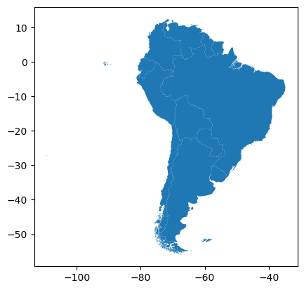

```python
# then

America=theMapAndData[theMapAndData.ranking=='South America']
America.plot()
```

A DDM can serve as an effective way to show the distribution of people. The most critical tasks are:

- Dot Placement: The dots should be randomly distributed within each polygon to avoid misrepresenting the data.
- Dot Unit: Deciding how many people each dot should represent is key for visual clarity. This value should be chosen carefully to avoid oversaturation or sparsity.

The size of all dots on the map must be the same to ensure a consistent visual comparison.

### Preprocessing: aggregating

This is a DOT UNIT proposal:

```python
justDots=America.copy()
dot_value = 0.1
justDots['num_dots'] = (justDots[' deaths/1'] / dot_value).astype(int)
```

### Preprocessing: distributing dots

And here, we get a location for the dots:

```python
# 2. Generate the random dot locations using .sample_points()
justDots = justDots.sample_points(size=justDots['num_dots']).explode(index_parts=True)
```

You get this:

```python
justDots
```

```
10   0     POINT (-71.86712 -42.41991)
     1     POINT (-71.17674 -50.56066)
     2     POINT (-71.03789 -45.43406)
     3     POINT (-70.26322 -48.82632)
     4      POINT (-70.1375 -44.74439)
                      ...
211  60      POINT (-61.60452 9.57513)
     61      POINT (-61.43101 9.71015)
     62      POINT (-61.23643 8.34536)
     63      POINT (-60.86948 6.88626)
     64      POINT (-60.31995 7.99799)
Name: sampled_points, Length: 924, dtype: geometry
```

```python
# what is it?
type(justDots)
```

```
geopandas.geoseries.GeoSeries
```

### Preprocessing: building GDF from GS

Notice the multi index (MI), one for a country and for a dot. As we are planing to send these points to R, we avoid MI:

```python
justDots.reset_index(drop=True, inplace=True)
America_dots=gpd.GeoDataFrame(geometry=justDots)
America_dots
```

|  | geometry |
| --- | --- |
| 0 | POINT (-71.86712 -42.41991) |
| 1 | POINT (-71.17674 -50.56066) |
| 2 | POINT (-71.03789 -45.43406) |
| 3 | POINT (-70.26322 -48.82632) |
| 4 | POINT (-70.1375 -44.74439) |
| ... | ... |
| 919 | POINT (-61.60452 9.57513) |
| 920 | POINT (-61.43101 9.71015) |
| 921 | POINT (-61.23643 8.34536) |
| 922 | POINT (-60.86948 6.88626) |
| 923 | POINT (-60.31995 7.99799) |

924 rows × 1 columns

Now you have a GDF:

```python
America_dots.info()
```

```
<class 'geopandas.geodataframe.GeoDataFrame'>
RangeIndex: 924 entries, 0 to 923
Data columns (total 1 columns):
 #   Column    Non-Null Count  Dtype
---  ------    --------------  -----
 0   geometry  924 non-null    geometry
dtypes: geometry(1)
memory usage: 7.3 KB
```

Juts plot the polygons as the base, and the points as the layer on top!

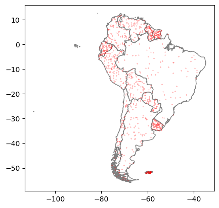

```python
base=America.plot(facecolor="white",#color of polygon fill
               edgecolor='grey') #color of border
America_dots.plot(markersize=0.05, color='red',ax=base)
```

It is generally recommended that DDMs use an **equal-area projection**, which benefits density and limits area distortion.

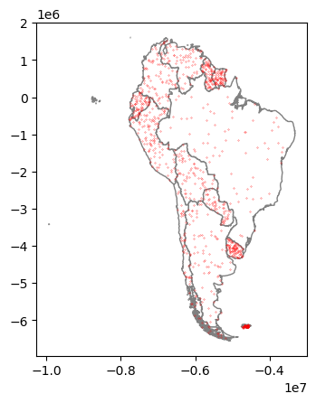

```python
base=America.to_crs(8857).plot(facecolor="white",
                              edgecolor='grey')
America_dots.to_crs(8857).plot(markersize=0.05, color='red',ax=base)
```

Let's keep the continent countries with that crs:

```python
America_8857=America.to_crs(8857)
America_dots_8857=America_dots.to_crs(8857)
```

# Thematics: the PSM (Proportional Symbol Map)

You have a PSM if you use a symbol (generally a circle) to show the distribution of a variable per location. The symbol is an aggregated raw value, and its size varies according to those values. So now we need:

### Preprocessing: GDF of centroids

1. A location for a symbol, generally the polygon centroid.

```python
America_8857_centroids = America_8857.copy()

# Africa_8857_centroids will have a new geometry:
America_8857_centroids['geometry'] = America_8857_centroids['geometry'].centroid
```

```python
America_8857_centroids['size'] = America_8857_centroids[' deaths/1'].apply(lambda x: (x**0.5) * 20)

## or
# import numpy as np
# Africa_8857_centroids['size'] = Africa_8857_centroids['population'].apply(lambda x: np.log10(x))
```

We got the basics, then:

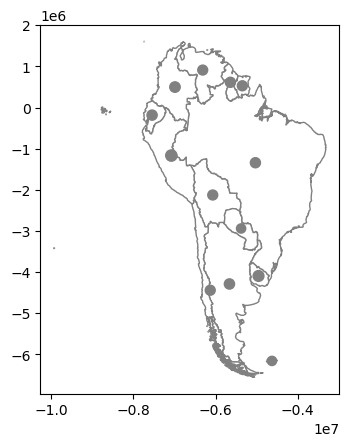

```python
base=America_8857.plot(facecolor="white",
                      edgecolor='grey')
# Plot the centroids on top
America_8857_centroids.plot(
    ax=base,
    markersize=America_8857_centroids['size'],
    color='grey'
)
```

```python
%pip install --user matplotlib
```

```python
%pip install --user mapclassify
```

```python
%pip install --user folium>=0.12" matplotlib mapclassify
```

```python
base=America_8857[America_8857.name=="SEYCHELLES"].explore()
America_8857_centroids[America_8857_centroids.name=="SEYCHELLES"].explore(m=base,color="red")
```

Make this Notebook Trusted to load map: File -> Trust Notebook

[interactive chart not shown]

A good alternative to centroids is representative_point() when dealing with complex multipolygons.

```python
# replace the points
America_8857_centroids["geometry"]=America_8857.representative_point()
```

We will keep that last result.

```python
base=America_8857[America_8857.name=="SEYCHELLES"].explore()
America_8857_centroids[America_8857_centroids.name=="SEYCHELLES"].explore(m=base,color="red")
```

Make this Notebook Trusted to load map: File -> Trust Notebook

[interactive chart not shown]

### Preprocessing: Computing new columns

PPMs are not thematic maps to see precise values, but to reveal clear differences on the variable distribution used. As, human eyes are very limited to detect area differences, we may need to use some other tactics to help uncover some patterns.

For example, let's confirm if we have outliers:

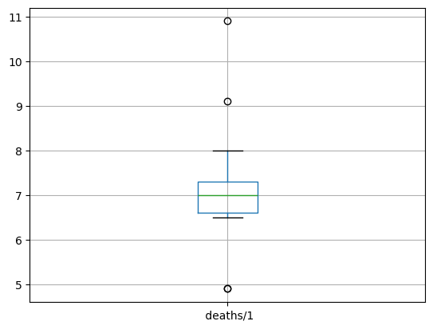

```python
boxplotInfo=America_8857_centroids.boxplot(column=' deaths/1',return_type="dict")
```

The object **boxplotInfo** showed the boxplot, and we confirm there are outliers. We can recover them like this:

```python
outliers=boxplotInfo['fliers'][0].get_ydata()
## see
outliers
```

```
array([4.9, 4.9, 10.9, 9.1], dtype=object)
```

Then, these are the outlying countries:

```python
America_8857_centroids[America_8857_centroids[' deaths/1'].isin(outliers)]
```

|  | name | geometry | slug | deaths/1 | 000 population | date_of_information | ranking | region | size |
| --- | --- | --- | --- | --- | --- | --- | --- | --- | --- |
| 70 | Falkland Islands (UK) | POINT (-4568163.973 -6166844.624) | falkland-islands-islas-malvinas | 4.9 | 2012 | 201 | South America | NaN | 44.271887 |
| 154 | Paraguay | POINT (-5383797.6 -2964049.838) | paraguay | 4.9 | 2024 | 196 | South America | NaN | 44.271887 |
| 155 | Peru | POINT (-7214274.314 -1170745.732) | peru | 10.9 | 2024 | 26 | South America | NaN | 66.030296 |
| 208 | Uruguay | POINT (-4944550.554 -4064051.998) | uruguay | 9.1 | 2024 | 57 | South America | NaN | 60.332413 |

Knowing this information, we can create a column as outlier flag:

```python
America_8857_centroids['population_outlier']=America_8857_centroids[' deaths/1'].isin(outliers)*1

## see
America_8857_centroids
```

|  | name | geometry | slug | deaths/1 | 000 population | date_of_information | ranking | region | size | population_outlier |
| --- | --- | --- | --- | --- | --- | --- | --- | --- | --- | --- |
| 10 | Argentina | POINT (-5553772.712 -4493827.822) | argentina | 7.3 | 2024 | 107 | South America | NaN | 54.037024 | 0 |
| 24 | Bolivia | POINT (-6065512.507 -2073238.575) | bolivia | 6.6 | 2024 | 130 | South America | NaN | 51.380930 | 0 |
| 29 | Brazil | POINT (-4700709.502 -1764170.762) | brazil | 7.0 | 2024 | 119 | South America | NaN | 52.915026 | 0 |
| 42 | Chile | POINT (-6234313.161 -4304799.911) | chile | 6.6 | 2024 | 133 | South America | NaN | 51.380930 | 0 |
| 47 | Colombia | POINT (-6936232.356 525486.665) | colombia | 8.0 | 2024 | 91 | South America | NaN | 56.568542 | 0 |
| 59 | Ecuador | POINT (-7496744.998 -227636.718) | ecuador | 7.2 | 2024 | 113 | South America | NaN | 53.665631 | 0 |
| 70 | Falkland Islands (UK) | POINT (-4568163.973 -6166844.624) | falkland-islands-islas-malvinas | 4.9 | 2012 | 201 | South America | NaN | 44.271887 | 1 |
| 89 | Guyana | POINT (-5636237.099 628135.992) | guyana | 7.0 | 2024 | 122 | South America | NaN | 52.915026 | 0 |
| 151 | Suriname | POINT (-5370305.407 503625.945) | suriname | 6.7 | 2024 | 129 | South America | NaN | 51.768716 | 0 |
| 154 | Paraguay | POINT (-5383797.6 -2964049.838) | paraguay | 4.9 | 2024 | 196 | South America | NaN | 44.271887 | 1 |
| 155 | Peru | POINT (-7214274.314 -1170745.732) | peru | 10.9 | 2024 | 26 | South America | NaN | 66.030296 | 1 |
| 208 | Uruguay | POINT (-4944550.554 -4064051.998) | uruguay | 9.1 | 2024 | 57 | South America | NaN | 60.332413 | 1 |
| 211 | Venezuela | POINT (-6245177.294 816095.879) | venezuela | 6.5 | 2024 | 137 | South America | NaN | 50.990195 | 0 |

We can use that like this:

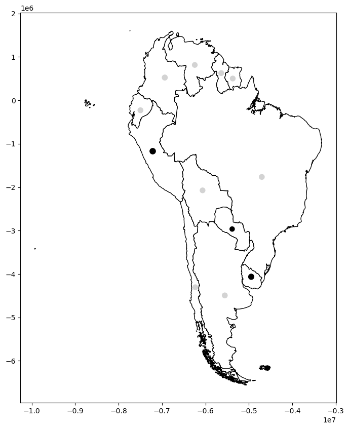

```python
base = America_8857.plot(color='white', edgecolor='black', figsize=(10,10))

# Define your color map
mapcolor = {1: 'black', 0: 'lightgrey'}

# Plot the centroids on top
America_8857_centroids.plot(
    ax=base,
    markersize=America_8857_centroids['size'],
    color=America_8857_centroids['population_outlier'].map(mapcolor)
)
```

Here, we do a good job for outliers, but it is difficult to interprete the other ones. We could use some redundancy, but more work is needed:

1. Create two maps of centroids:

```python
# Create explicit copies of the DataFrames
America_8857_centroids_out = America_8857_centroids[America_8857_centroids.population_outlier==1].copy()
America_8857_centroids_no_out = America_8857_centroids[America_8857_centroids.population_outlier==0].copy()
```

2. Compute sizes in each:

```python
America_8857_centroids_out['size'] = America_8857_centroids_out[' deaths/1'].apply(lambda x: x**0.5*10)
America_8857_centroids_no_out['size'] = America_8857_centroids_no_out[' deaths/1'].apply(lambda x: x**0.5*10)
```

Now, plot the three layers, using some color gradient for the non-outliers:

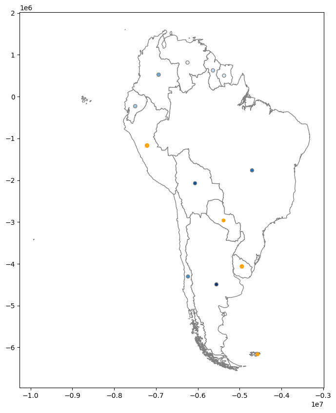

```python
base = America.to_crs(America_8857_centroids_no_out.crs).plot(color='white', edgecolor='grey', figsize=(10,10))


America_8857_centroids_no_out.plot(
    ax=base,
    markersize=America_8857_centroids_no_out['size'],
    edgecolor='grey',
    c=America_8857_centroids_no_out['size'],
    cmap='Blues_r'
)
America_8857_centroids_out.plot(
    ax=base,
    markersize=America_8857_centroids_out['size'],
    color='orange'
)
```

# Thematics: Choropleths

Notice that the DDMs may use aggregated counts, and the PSMs use the variables in its original form. Choropleths will 'paint' the whole polygon and as noticed in PSMs, we have to be very careful when using color in shape, as the area itself is a confounding. To control this visual artifact, the variable must be normalized, that is, divided by a value correlated with the area.

Then, for this course, a choropleth is a normalized representation of data.

Following our definition:

- This is **NOT** a choropleth:

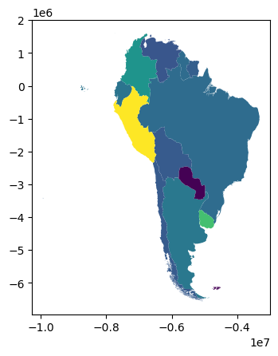

```python
America_8857.plot(America_8857[' deaths/1'])
```

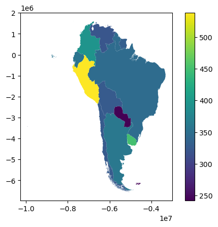

```python
# Tasa de muertes por cada 100,000 habitantes
America_8857['death_rate'] = (America_8857[' deaths/1'] / America_8857['000 population']) * 100000

# Graficar coroplético de tasa de muertes
America_8857.plot(column='death_rate', legend=True, cmap="viridis")
```

Choropleths are great to represent normalized indicators such as:

- Densities
- Ratios
- Rates
- Averages

Population by area is a density indicator. This is a real number (not an integer), so most of the time the color gradient might not be that useful to reveal some pattern visually. Then, we often discretize (or bin) the indicator computed.

### Preprocessing: Discretizing

Now, we want to cut the variable. Run the next code to make sure you have tose packages:

```python
## do you have these installed?
%pip show numba user mapclassify numpy
```

[output not shown]

```
WARNING: Package(s) not found: numba, user
```

We will discretize this:

```python
America_8857['death_rate']=(America_8857[' deaths/1'] / America_8857['000 population'])
```

Let's explore the bining algorithms:

```python
import mapclassify
import numpy as np

np.random.seed(12345) # so we all get the same results!

# let's try 5 intervals
K=5
theVar=America_8857['death_rate']
# same interval width, easy interpretation
ei5 = mapclassify.EqualInterval(theVar, k=K)
# same interval width based on standard deviation, easy - but not as the previous one, poor when high skewness
msd = mapclassify.StdMean(theVar)
# interval width varies, counts per interval are close, not easy to grasp, repeated values complicate cuts
q5=mapclassify.Quantiles(theVar,k=K)

# based on similarity, good for multimodal data
mb5 = mapclassify.MaximumBreaks(theVar, k=K)
# based on similarity, good for skewed data
ht = mapclassify.HeadTailBreaks(theVar) # no K needed
# based on similarity, optimizer
fj5 = mapclassify.FisherJenks(theVar, k=K)
# based on similarity, optimizer
jc5 = mapclassify.JenksCaspall(theVar, k=K)
# based on similarity, optimizer
mp5 = mapclassify.MaxP(theVar, k=K)
```

How can we select the right classification? Let me use the the Absolute deviation around class median (ADCM) to make the comparisson:

```python
class5 = ei5,msd, q5,mb5,  ht, fj5, jc5, mp5
# Collect ADCM for each classifier
fits = np.array([ c.adcm for c in class5])
# Convert ADCM scores to a DataFrame
adcms = pd.DataFrame(fits)
# Add classifier names
adcms['classifier'] = [c.name for c in class5]
# Add column names to the ADCM
adcms.columns = ['ADCM', 'Classifier']
```

Now, plot the **adcms**:

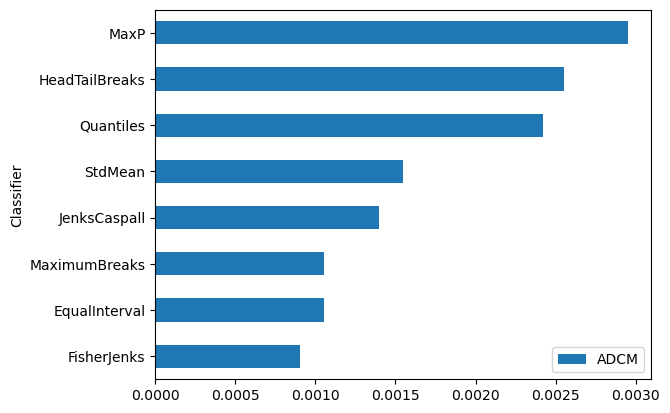

```python
adcms.sort_values('ADCM').plot.barh(x='Classifier')
```

Let's save the best strategy:

```python
America_8857['death_rate_FJ5'] = fj5.yb
```

```python
# there you are
America_8857[['death_rate','death_rate_FJ5']].head(20)
```

|  | death_rate | death_rate_FJ5 |
| --- | --- | --- |
| 10 | 0.003607 | 2 |
| 24 | 0.003261 | 1 |
| 29 | 0.003458 | 1 |
| 42 | 0.003261 | 1 |
| 47 | 0.003953 | 2 |
| 59 | 0.003557 | 2 |
| 70 | 0.002435 | 0 |
| 89 | 0.003458 | 1 |
| 151 | 0.003310 | 1 |
| 154 | 0.002421 | 0 |
| 155 | 0.005385 | 4 |
| 208 | 0.004496 | 3 |
| 211 | 0.003211 | 1 |

We could create a copy of the bins to add labels:

```python
# renaming
newLabelsForLevels={0:"0_VeryLow", 1:"1_Low", 2:"2_Middle", 3:"3_High", 4:"4_VeryHigh"}

America_8857['death_rate_FJ5_cat']=America_8857.loc[:,'death_rate_FJ5'].replace(newLabelsForLevels)

# we have
America_8857[['death_rate','death_rate_FJ5','death_rate_FJ5_cat']].head(20)
```

|  | death_rate | death_rate_FJ5 | death_rate_FJ5_cat |
| --- | --- | --- | --- |
| 10 | 0.003607 | 2 | 2_Middle |
| 24 | 0.003261 | 1 | 1_Low |
| 29 | 0.003458 | 1 | 1_Low |
| 42 | 0.003261 | 1 | 1_Low |
| 47 | 0.003953 | 2 | 2_Middle |
| 59 | 0.003557 | 2 | 2_Middle |
| 70 | 0.002435 | 0 | 0_VeryLow |
| 89 | 0.003458 | 1 | 1_Low |
| 151 | 0.003310 | 1 | 1_Low |
| 154 | 0.002421 | 0 | 0_VeryLow |
| 155 | 0.005385 | 4 | 4_VeryHigh |
| 208 | 0.004496 | 3 | 3_High |
| 211 | 0.003211 | 1 | 1_Low |

We are ready for a discrete choropleth:

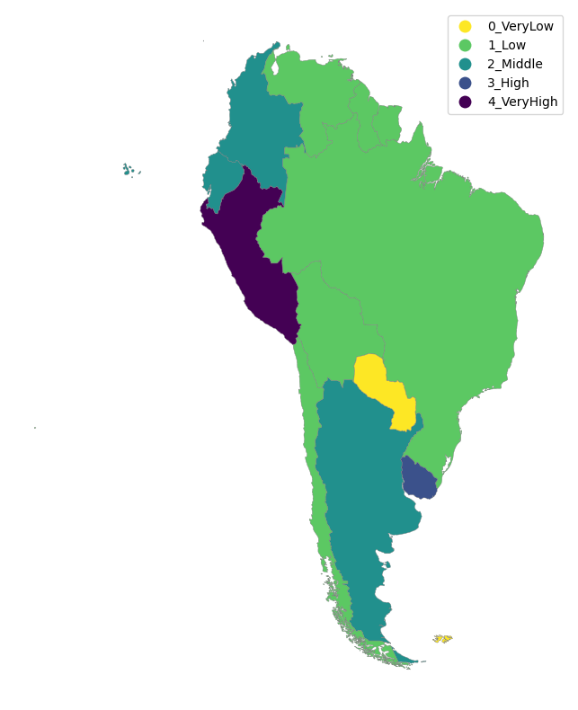

```python
import matplotlib.pyplot as plt

f, ax = plt.subplots(1, figsize=(10, 10))
America_8857.plot(column='death_rate_FJ5_cat', # variable to plot
                 cmap='viridis_r', # set of colors
                 categorical=True, # can be interpreted as category
                 edgecolor='grey', # border color
                 linewidth=0.3, # width of border
                 legend=True, # need a legend?
                 ax=ax
       )

ax.set_axis_off()
```

# Saving

Let's save this maps for R.

```python
## Good practice to refresh your memory

## Find only GeoDataFrames in the current session
geodataframe_list = [var for var in globals() if isinstance(globals()[var], gpd.GeoDataFrame)]

print("List of GeoDataFrames in memory:")
for name in geodataframe_list:
    print(name)
```

```
List of GeoDataFrames in memory:
countries
_3
theMapAndData
America
America_dots
_32
America_8857
America_dots_8857
America_8857_centroids
_48
_49
America_8857_centroids_out
America_8857_centroids_no_out
```

These are the ones needed in R:

```python
# for choropleth and base map
America_8857.info()
```

```
<class 'geopandas.geodataframe.GeoDataFrame'>
Index: 13 entries, 10 to 211
Data columns (total 11 columns):
 #   Column               Non-Null Count  Dtype
---  ------               --------------  -----
 0   name                 13 non-null     object
 1   geometry             13 non-null     geometry
 2   slug                 13 non-null     object
 3    deaths/1            13 non-null     float64
 4   000 population       13 non-null     int64
 5   date_of_information  13 non-null     int64
 6   ranking              13 non-null     object
 7   region               0 non-null      float64
 8   death_rate           13 non-null     float64
 9   death_rate_FJ5       13 non-null     int64
 10  death_rate_FJ5_cat   13 non-null     object
dtypes: float64(3), geometry(1), int64(3), object(4)
memory usage: 1.2+ KB
```

```python
# for DDMs
America_dots_8857.info()
```

```
<class 'geopandas.geodataframe.GeoDataFrame'>
RangeIndex: 924 entries, 0 to 923
Data columns (total 1 columns):
 #   Column    Non-Null Count  Dtype
---  ------    --------------  -----
 0   geometry  924 non-null    geometry
dtypes: geometry(1)
memory usage: 7.3 KB
```

```python
# for PSMs
America_8857_centroids.info()
```

```
<class 'geopandas.geodataframe.GeoDataFrame'>
Index: 13 entries, 10 to 211
Data columns (total 10 columns):
 #   Column               Non-Null Count  Dtype
---  ------               --------------  -----
 0   name                 13 non-null     object
 1   geometry             13 non-null     geometry
 2   slug                 13 non-null     object
 3    deaths/1            13 non-null     float64
 4   000 population       13 non-null     int64
 5   date_of_information  13 non-null     int64
 6   ranking              13 non-null     object
 7   region               0 non-null      float64
 8   size                 13 non-null     float64
 9   population_outlier   13 non-null     int64
dtypes: float64(3), geometry(1), int64(3), object(3)
memory usage: 1.1+ KB
```

```python
# for PSMs
America_8857_centroids_out.info()
```

```
<class 'geopandas.geodataframe.GeoDataFrame'>
Index: 4 entries, 70 to 208
Data columns (total 10 columns):
 #   Column               Non-Null Count  Dtype
---  ------               --------------  -----
 0   name                 4 non-null      object
 1   geometry             4 non-null      geometry
 2   slug                 4 non-null      object
 3    deaths/1            4 non-null      float64
 4   000 population       4 non-null      int64
 5   date_of_information  4 non-null      int64
 6   ranking              4 non-null      object
 7   region               0 non-null      float64
 8   size                 4 non-null      float64
 9   population_outlier   4 non-null      int64
dtypes: float64(3), geometry(1), int64(3), object(3)
memory usage: 352.0+ bytes
```

```python
# for PSMs
America_8857_centroids_no_out.info()
```

```
<class 'geopandas.geodataframe.GeoDataFrame'>
Index: 9 entries, 10 to 211
Data columns (total 10 columns):
 #   Column               Non-Null Count  Dtype
---  ------               --------------  -----
 0   name                 9 non-null      object
 1   geometry             9 non-null      geometry
 2   slug                 9 non-null      object
 3    deaths/1            9 non-null      float64
 4   000 population       9 non-null      int64
 5   date_of_information  9 non-null      int64
 6   ranking              9 non-null      object
 7   region               0 non-null      float64
 8   size                 9 non-null      float64
 9   population_outlier   9 non-null      int64
dtypes: float64(3), geometry(1), int64(3), object(3)
memory usage: 792.0+ bytes
```

```python
America_8857.to_file("america_8857.gpkg",driver='GPKG',layer='continent')
America_dots_8857.to_file("america_8857.gpkg",driver='GPKG',layer='population_ddm')
America_8857_centroids.to_file("america_8857.gpkg",driver='GPKG',layer='population_psm')
America_8857_centroids_out.to_file("america_8857.gpkg",driver='GPKG',layer='outlier_population_psm')
America_8857_centroids_no_out.to_file("america_8857.gpkg",driver='GPKG',layer='no_outlier_population_psm')
```